# Predictors of Scene Timing Performance Following Concussion

Multiple Regression Analysis — PSYC 6132

2026-03-31

# a) Research Problem & Theoretical Rationale

Concussion is a mild traumatic brain injury that disrupts cognitive and sensorimotor processing. Individuals recovering from concussion commonly experience dizziness, impaired balance, slowed reaction times, and difficulties with visual-spatial navigation — all of which may impair performance on timed, real-world tasks.

The **scene timing composite** (8TimingComp) captures the efficiency with which a participant completes a structured scene task, providing an ecologically valid index of functional performance. We hypothesise that **post-concussion symptom severity** — as measured by validated clinical scales — will predict slower (i.e., worse) performance on this task, over and above the effects of demographic characteristics and time since injury.

# b) Variables

**Criterion variable**

| Variable | Description | Scale |
| --- | --- | --- |
| 8TimingComp | Scene completion time composite | Continuous (z-scored composite; higher = slower performance) |

**Predictors**

| Variable | Description | Scale |
| --- | --- | --- |
| AGE | Participant age | Continuous (years) |
| Sex_Recode_F1M0 | Biological sex | Binary (0 = Male, 1 = Female) |
| DHI | Dizziness Handicap Inventory | Continuous (0–100; higher = greater dizziness handicap) |
| RPQ_3 | Rivermead Post-Concussion Symptoms — 3 early symptoms | Continuous (0–12; higher = more severe) |
| RPQ_13 | Rivermead Post-Concussion Symptoms — 13 later symptoms | Continuous (0–52; higher = more severe) |
| DaysSinceLastConcussion | Days elapsed since most recent concussion (control variable) | Continuous (days) |

# c) Regression Equation

The model takes the form:

$$\hat{Y} = b_0 + b_1(\text{AGE}) +
b_2(\text{Sex}) + b_3(\text{DHI}) + b_4(\text{RPQ\_3}) +
b_5(\text{RPQ\_13}) + b_6(\text{DaysSinceLastConcussion}) +
\varepsilon$$

Where $\hat{Y}$ is the predicted scene timing composite, $b_0$ is the intercept, $b_1$–$b_6$ are the unstandardised regression coefficients, and $\varepsilon$ is the residual error term.

|  | Predictor | b | SE | t | p |
| --- | --- | --- | --- | --- | --- |
| (Intercept) | Intercept | -4.122 | 1.318 | -3.129 | 0.004 |
| AGE | AGE | 0.074 | 0.023 | 3.287 | 0.002 |
| Sex_Recode_F1M0 | Sex (F=1, M=0) | 0.697 | 0.485 | 1.436 | 0.160 |
| DHI | DHI | 0.024 | 0.012 | 1.926 | 0.063 |
| RPQ_3 | RPQ_3 | 0.123 | 0.125 | 0.983 | 0.332 |
| RPQ_13 | RPQ_13 | -0.034 | 0.026 | -1.305 | 0.201 |
| DaysSinceLastConcussion | Days Since Last Concussion | 0.000 | 0.000 | -1.699 | 0.098 |

**DAG: Variable Relationships**

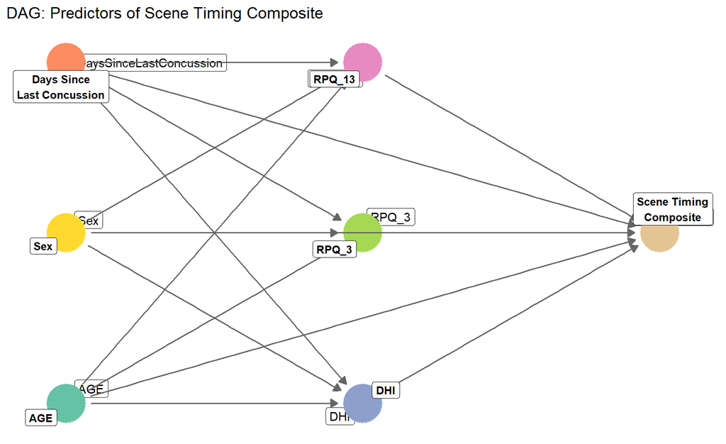

# d) Critical Test

The critical elements are the **symptom severity predictors**: DHI, RPQ_3, and RPQ_13.

The central hypothesis is that **greater post-concussion symptom burden predicts worse (slower) scene timing performance**, even after controlling for age, sex, and days since last concussion. Specifically, we expect one or more of $b_3$ (DHI), $b_4$ (RPQ_3), and $b_5$ (RPQ_13) to be **positive and statistically significant** (*p* < .05), indicating that higher symptom scores are associated with a higher (worse) timing composite.

The inclusion of **DaysSinceLastConcussion** as a covariate is important: without it, the symptom coefficients could be confounded by recovery duration — symptom scores naturally decrease over time, and performance may improve independently of symptom level. Controlling for days since injury isolates the *concurrent* relationship between symptom severity and performance.

# e) Assumption Checks

### 1. Linearity

**Residuals vs. Fitted (composite)**

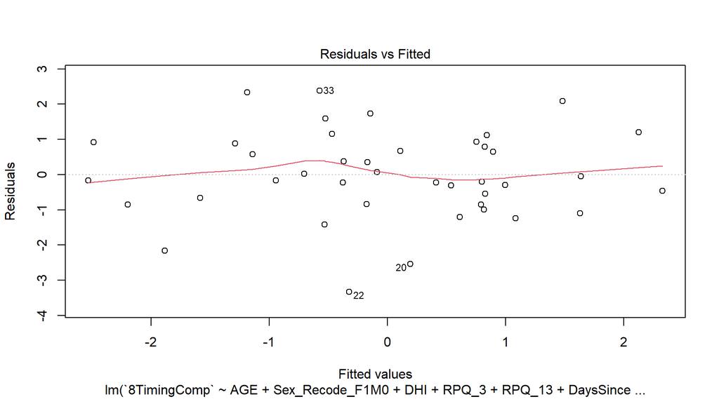

Look for random scatter around the horizontal zero line. A systematic curve or U-shape indicates non-linearity in the model’s linear combination of predictors.

**Added-Variable Plots (per predictor)**

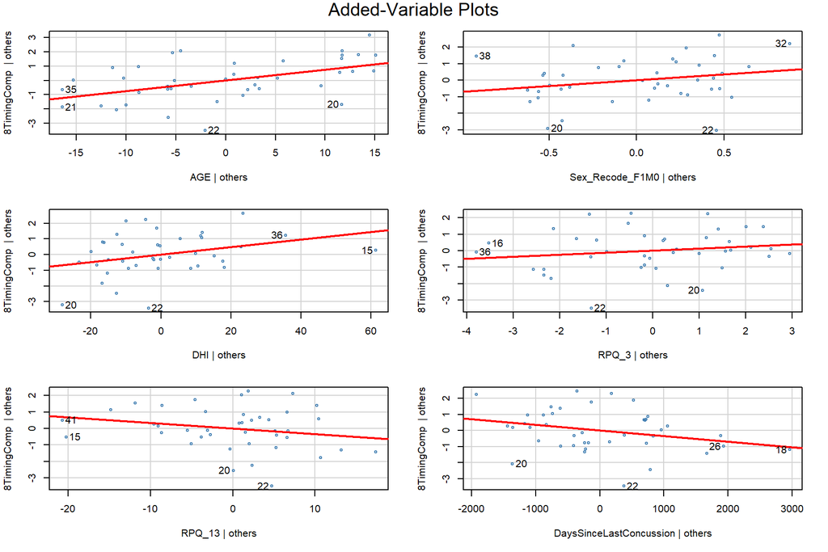

Each panel shows the unique linear relationship between one predictor and the outcome after partialling out all others. A roughly linear trend in each panel is expected; a curve flags a problem for that specific predictor.

### 2. Normality

**Q-Q Plot of Residuals**

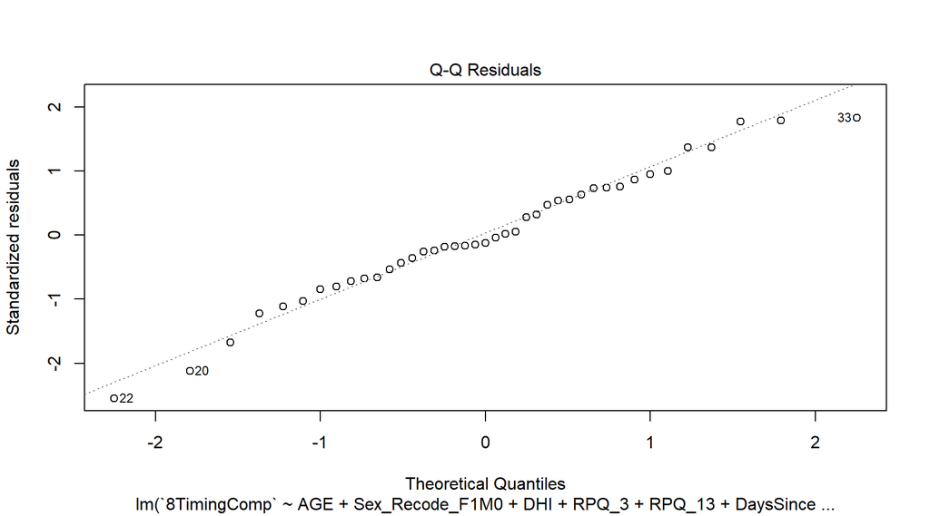

Points should follow the diagonal reference line closely. Systematic S-curves or pronounced heavy tails indicate departures from normality. In small samples this can inflate Type I error rates and distort confidence intervals; in large samples the central limit theorem provides some protection.

### 3. Homoscedasticity

**Scale-Location Plot**

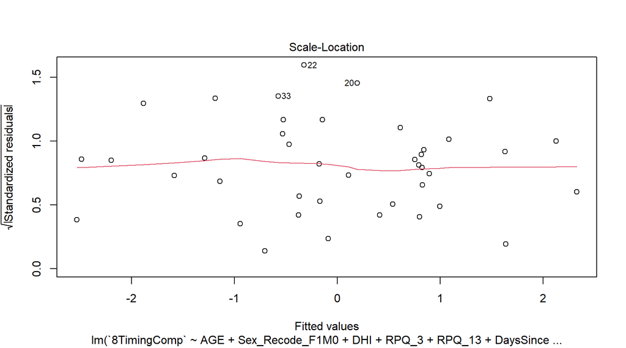

The LOESS line should be roughly horizontal with consistent spread across the range of fitted values. A rising trend or funnel shape indicates heteroscedasticity, which produces biased standard errors and distorts *p*-values and confidence intervals.

### 4. Independence

**Residuals vs. Observation Order**

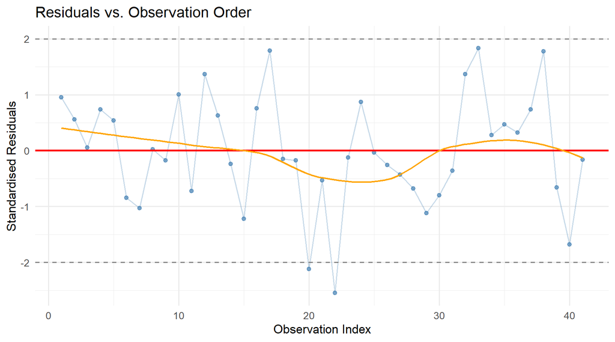

No systematic trend, wave, or drift across the observation sequence is expected. A pattern suggests autocorrelation or a data-collection order effect, which violates the assumption that observations are independent.

### 5. Multicollinearity

**Predictor Correlation Heat Map**

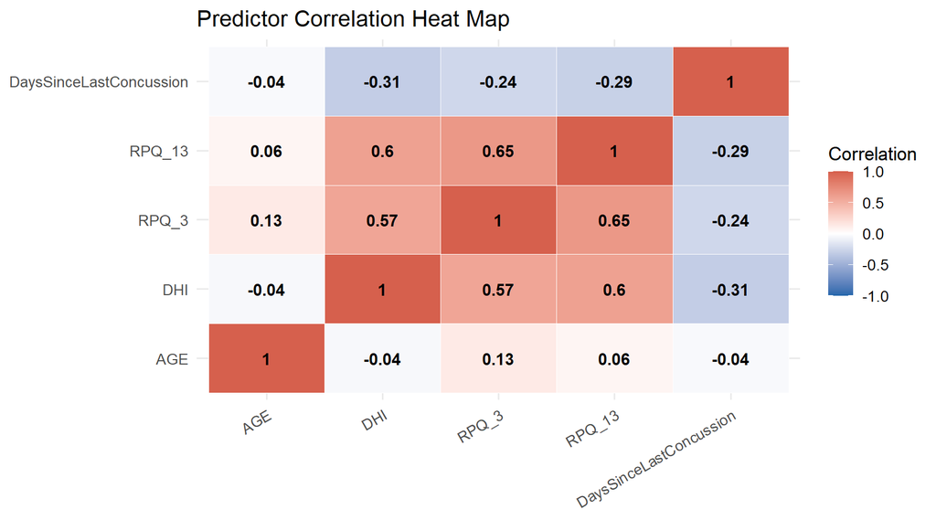

**VIF Bar Chart**

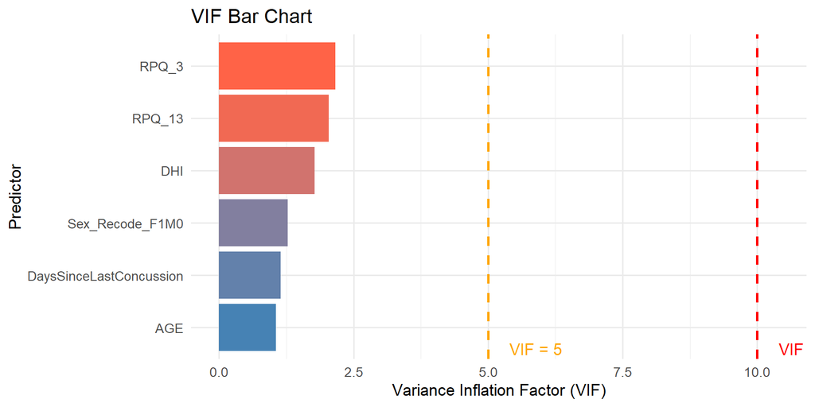

Correlations approaching ±0.80 between predictors are concerning. RPQ_3 and RPQ_13 are likely to be moderately correlated given they are subscales of the same instrument. VIF > 5 indicates moderate concern; VIF > 10 indicates serious multicollinearity that inflates standard errors and destabilises coefficient estimates.

### 6. Fixed Predictors

**Predictor Distributions**

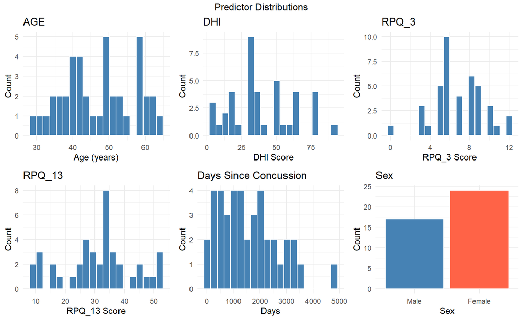

Distributions should be plausible and free of implausible extreme values that would suggest data-entry errors or gross measurement anomalies. Extreme outliers in any continuous predictor can exert undue leverage on the regression solution.

# f) Conclusion & Interpretation

**Overall model fit:** The model accounted for **R² = 0.475** of the variance in scene timing performance (adjusted R² = 0.383), *F*(6, 34) = 5.14, *p* = 0.001.

**Coefficient table** (significant predictors highlighted):

|  | Predictor | b | SE | t | p |
| --- | --- | --- | --- | --- | --- |
| (Intercept) | Intercept | -4.122 | 1.318 | -3.129 | 0.004 |
| AGE | AGE | 0.074 | 0.023 | 3.287 | 0.002 |
| Sex_Recode_F1M0 | Sex (F=1, M=0) | 0.697 | 0.485 | 1.436 | 0.160 |
| DHI | DHI | 0.024 | 0.012 | 1.926 | 0.063 |
| RPQ_3 | RPQ_3 | 0.123 | 0.125 | 0.983 | 0.332 |
| RPQ_13 | RPQ_13 | -0.034 | 0.026 | -1.305 | 0.201 |
| DaysSinceLastConcussion | Days Since Last Concussion | 0.000 | 0.000 | -1.699 | 0.098 |

A positive *b* coefficient indicates that higher scores on that variable are associated with a slower (worse) scene timing composite, holding all other predictors constant. Rows highlighted in blue are statistically significant at *p* < .05.

**Assumptions summary:**

[output not shown]